# Exercise-4_HaozhenHong(999001233)

### Exploring the count tables

Here, import an example count table and do some exploration of the expression data.

```r
counts_file <- system.file("extdata/rna-seq/SRP029880.raw_counts.tsv",
                           package = "compGenomRData")
coldata_file <- system.file("extdata/rna-seq/SRP029880.colData.tsv",
                            package = "compGenomRData")
```

Load the packages needed.

```r
library(pheatmap)
library(corrplot)
```

1. Normalize the counts using the TPM approach.

```r
# Load the table
counts <- read.table(counts_file)
# Obtain gene length for rpkm
genelength <- as.vector(counts[,'width'])
# Obtain RPKM
rpkm <- apply(subset(counts, select = c(-width)), 2, function(x) 10^9*x/genelength/sum(x))
# Obtain TPM
tpm <- apply(rpkm, 2, function(x) 10^6*x/sum(x))
# Check the sum of each column equals to 10^6
colSums(tpm)
```

```
## CASE_1 CASE_2 CASE_3 CASE_4 CASE_5 CTRL_1 CTRL_2 CTRL_3 CTRL_4 CTRL_5
##  1e+06  1e+06  1e+06  1e+06  1e+06  1e+06  1e+06  1e+06  1e+06  1e+06
```

2. Plot a heatmap of the top 500 most variable genes. Compare with the heatmap obtained using the 100 most variable genes. Hint : use var() function to compute the variance.

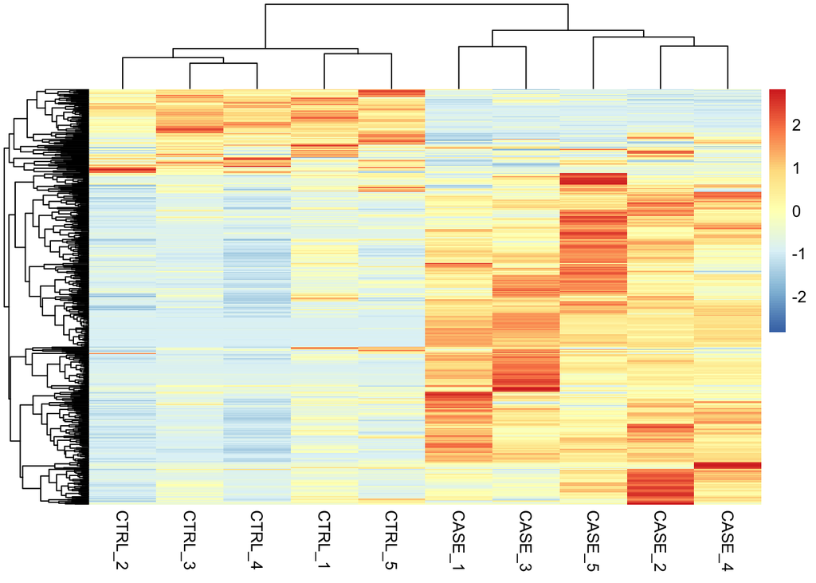

```r
# Compute the variance of each gene.
V <- apply(tpm, 1, var)
# Select 500 most variable genes.
gene_top500 <- names(V[order(V, decreasing = T)])[1:500]
# Draw the heat map.
pheatmap(tpm[gene_top500,], scale = 'row', show_rownames = F)
```

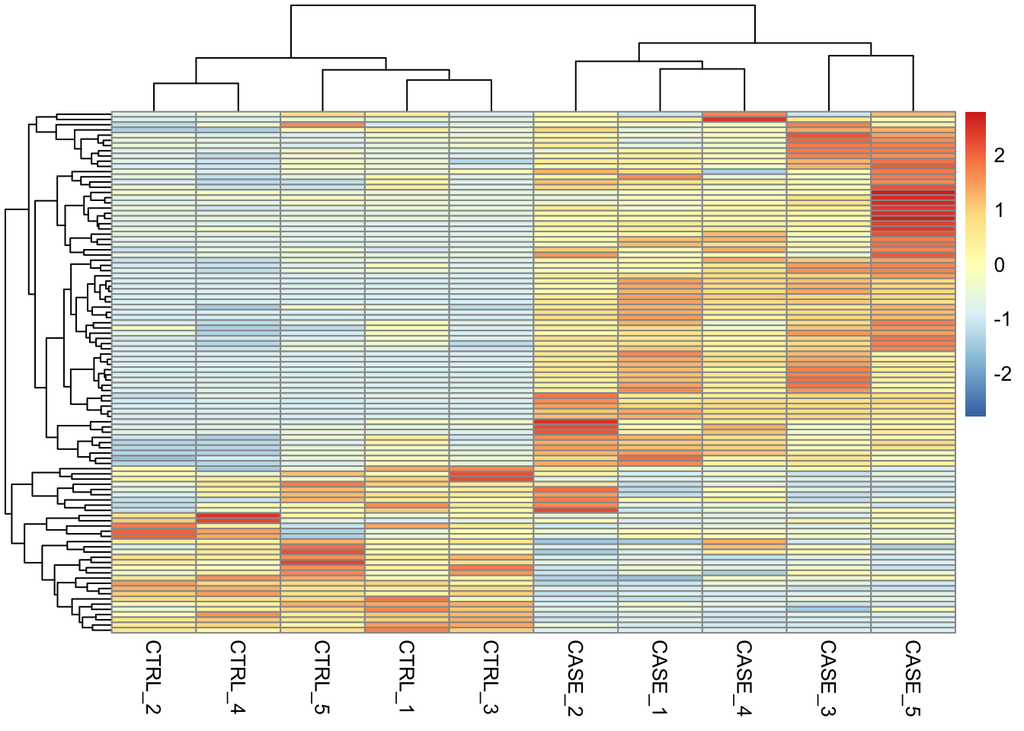

[output not shown]

```r
# Same ops to the top 100 most variable genes.
gene_top100 <- names(V[order(V, decreasing = T)])[1:100]
pheatmap(tpm[gene_top100,], scale = 'row', show_rownames = F)
```

3. Re-do the heatmaps setting the `scale` argument to `none`, and `column`. Compare the results with `scale = 'row'`.

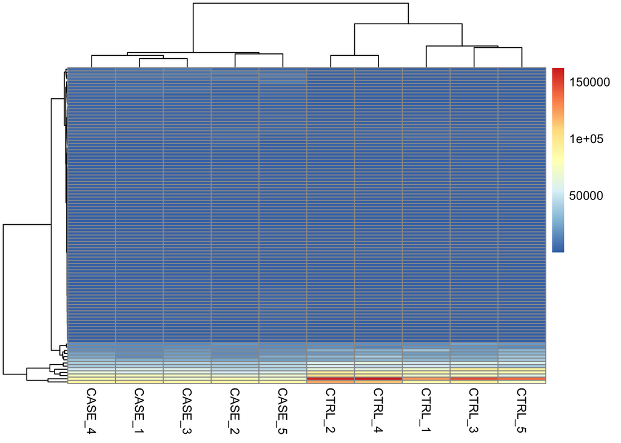

```r
pheatmap(tpm[gene_top100,], scale = 'none', show_rownames = F)
```

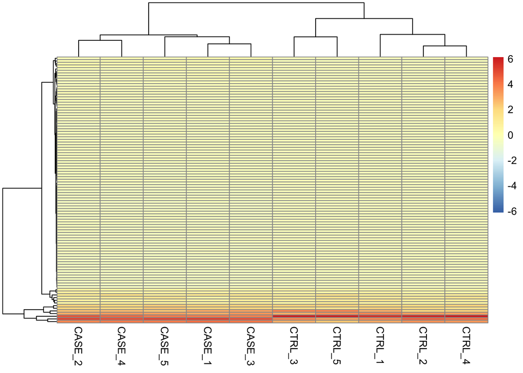

```r
pheatmap(tpm[gene_top100,], scale = 'column', show_rownames = F)
```

```r
paste("scale = 'row' enables us to see the variance in each gene, while the other settings can not.")
```

[output not shown]

4. Draw a correlation plot for the samples depicting the sample differences as ‘ellipses’, drawing only the upper end of the matrix, and order samples by hierarchical clustering results based on `average` linkage clustering method.

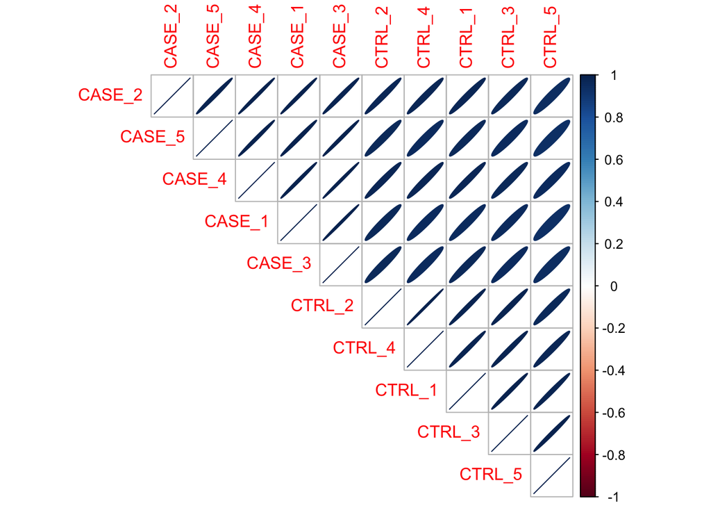

```r
# Generate correlation matrix
correlationMatrix <- cor(tpm)

# Correlation plot
corrplot(correlationMatrix,
         method = "ellipse",
         type = "upper",
         order = "hclust",
         hclust.method = "average")
```

### Git and Github

5. Open Github account, and install git if it required as instructed in the following link: https://github.com/llendway/github_for_collaboration/blob/master/github_for_collaboration.md
6. Create a repository and commit and push the answers of this exercise through Rtudio (Please upload the answers to the exercises also to Moodle).
7. Insert the link to your Github account here.

Link: https://github.com/HaozhenHZ/Exercise-4